# Cancelled Flights

Rong Du

5/4/2016

[Home](http://web.engr.illinois.edu/~jknguye2/delays.html)

### Introduction

In this section, I mainly focus on the study of flight cancellation during year 1997 and 1998.

```r
# Preparation Code

setwd("~/container-data/project")
library(ggplot2)
library(treemap)
library(dplyr)
library(graphics)
library(grDevices)
library(plotly)
library(gridExtra)

# Create Cancel Data

cancelmday <- read.csv("cancel_mday.csv", header = TRUE, sep = ',')
colnames(cancelmday) <- c("year","month","dayofmonth","dayofweek","numcancel","numflight")
cancelmday$ratio <- cancelmday$numcancel/cancelmday$numflight
cancelmday$year <- as.factor(cancelmday$year)
```

### Questions

**(1)** **What are the differences between 1997 and 1998 in terms of flight cancellation?**

**(2)** **Which months are prone to more cancel? What about day of week?**

I applied Hive to calculate the number of cancelled flights each day for the two years and would like to see the cancellation distribution for different months, day of week. Meanwhile, make comparison between years.

Several visualization plots well summarizes the above question.

### Analysis

**(1)** **Distribution of months’ cancel in two years**

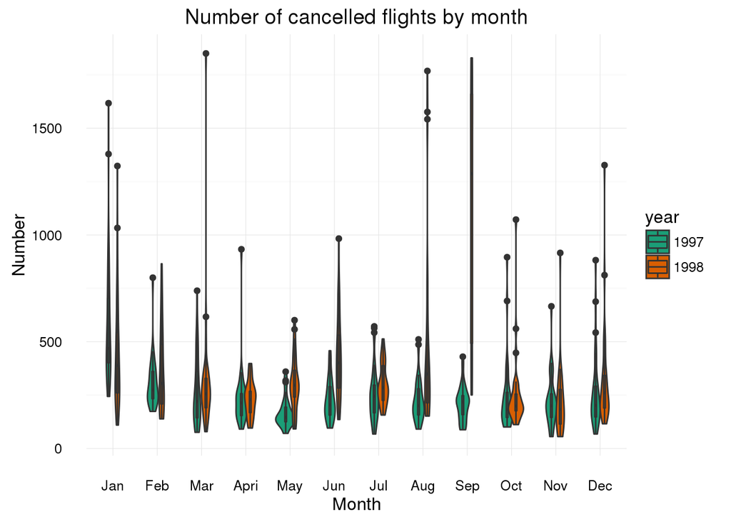

```r
(violin_cancel <- ggplot(cancelmday, aes(x = as.factor(month), y = numcancel, fill = year)) +
                       geom_violin(position = position_dodge(width = 0.4)) +
                       geom_boxplot(aes(fill = as.factor(year)), width = 0.1, position = position_dodge(width = 0.4)) +
                       labs(title = "Number of cancelled flights by month", x = "Month", y = "Number") +
                       scale_fill_brewer(palette="Dark2") + theme_minimal() +
                       scale_x_discrete(labels = c("Jan","Feb","Mar","Apri","May","Jun","Jul","Aug","Sep","Oct","Nov","Dec")))
```

**(2)** **Number of cancellation in two years with month measurement**

[interactive chart not shown]

[figure not shown]

```r
bar_cancel <- ggplot(cancelmday, aes(x = as.factor(month), y = numcancel, fill = year)) +
                     stat_summary(fun.y = sum, position = position_dodge(), geom = "bar") +
                     labs(title = "Cancel flights comparison", x = "Month", y = "Number" ) +
                     scale_fill_brewer(palette="Greens") + theme_minimal() +
                     scale_x_discrete(labels = c("Jan","Feb","Mar","Apri","May","Jun","Jul","Aug","Sep","Oct","Nov","Dec"))
ggplotly(bar_cancel)
```

Considering the overall number of cancelled flights rather than density, there is still an increase trend from 1997 to 1998. Concerning months, September, January and August still stands out.

**(3)** **Heat Map of cancellation**

```r
# separate cancel data in two years
cancel1997 <- cancelmday[cancelmday[,1]==1997,c(1,2,4,7)]
cancel1997$month <- as.factor(cancel1997$month)
cancel1997$dayofweek <- as.factor(cancel1997$dayofweek)

cancel1998 <- cancelmday[cancelmday[,1]==1998,c(1,2,4,7)]
cancel1998$month <- as.factor(cancel1998$month)
cancel1998$dayofweek <- as.factor(cancel1998$dayofweek)
```

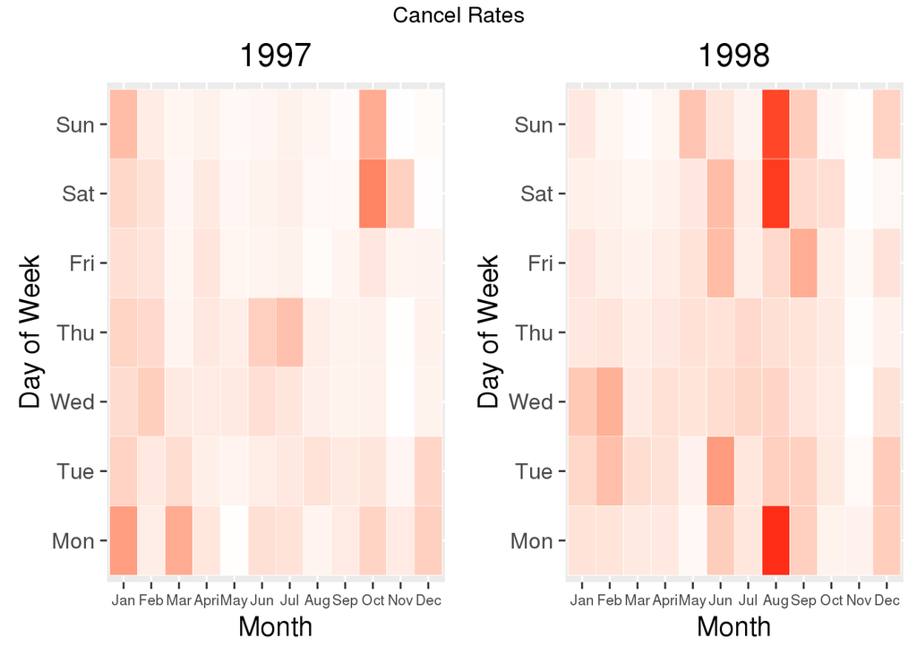

```r
base_size <- 15

rate1997 <- ggplot(cancel1997, aes(month, dayofweek)) + geom_tile(aes(fill = ratio), colour = "white") +
  scale_fill_gradient(low = "white",high = "red") +  theme_grey(base_size = base_size) +
  labs(x = "Month", y = "Day of Week") +
  scale_x_discrete(labels = c("Jan","Feb","Mar","Apri","May","Jun","Jul","Aug","Sep","Oct","Nov","Dec")) +
  scale_y_discrete(labels = c("Mon","Tue","Wed","Thu","Fri","Sat","Sun")) +
  ggtitle("1997") + theme(legend.position="none") +
  theme(axis.text.x=element_text(size=8))

rate1998 <- ggplot(cancel1998, aes(month, dayofweek)) + geom_tile(aes(fill = ratio), colour = "white") +
  scale_fill_gradient(low = "white",high = "red") +  theme_grey(base_size = base_size) +
  labs(x = "Month", y = "Day of Week") +
  scale_x_discrete(labels = c("Jan","Feb","Mar","Apri","May","Jun","Jul","Aug","Sep","Oct","Nov","Dec")) +
  scale_y_discrete(labels = c("Mon","Tue","Wed","Thu","Fri","Sat","Sun")) +
  ggtitle("1998") + theme(legend.position="none") +
  theme(axis.text.x=element_text(size=8))

grid.arrange(rate1997, rate1998, ncol = 2, top = "Cancel Rates")
```

I basically suggest that cancelled flights itself does not speak as powerfully as the cancellation rates because the high number of cancelled flights might due to the total large number of flights.

As a result of this idea, I came up withe the heat maps with x-axis months and y-axis day of week. Color indicates cancellation ratio.

There is a little surprise that it is not completely in agreement with the above plots. In 1997, the highest cancellation rates appear in October instead of August. For 1998, there’s not much conflict. The greatest cancel are usually at weekends when it comes to day of week. However in 1998, Monday suffer large cancellation ratio as well.

### Conclusions

**(1)** **Cancellation trend between years**

The number of canceled flights generally increase from 1997 to 1998 and cancellation rates go up meanwhile. It is a possible reason of the strenghened effect of “1997–98 El Niño event” (Wiki-pedia).

**(3)** **Flight cancel rates measured by month and day of week**

In 1997, October and January have the hugest cancel rates however August, June and September result in the greatest cancel rates in 1998. Both years have canceling rates the higest at weekends. 1998 sees Monday’s cancellation peak.